# Homework 06

## Question 1: Compare KNN and logistic regression

Use breast-cancer.csv, which contains 569 cases from the [Wisconsin Diagnostic Breast Cancer dataset](https://archive.ics.uci.edu/dataset/17/breast%2Bcancer%2Bwisconsin%2Bdiagnostic). Predict `y` (1 for malignant and 0 for benign) using `mean_radius`, `mean_texture`, and `mean_smoothness`.

Set a random seed and randomly split the observations into 70% training and 30% test data. Use the same split for every model. Standardize the predictors using the training means and standard deviations, and apply the same transformations to the test data.

Fit ordinary logistic regression with an intercept and no penalty, and KNN with Euclidean distance, equal neighbor weights, and

$$k\in\{5,15,25,35,45\}.$$

Using the estimated probabilities for `y = 1` on the test data, plot all six ROC curves in one figure and report their AUC values. Which of the six fitted models do you prefer? Give a brief justification based on your results.

```r
library(FNN)
library(pROC)
data_dir <- if (file.exists("data/breast-cancer.csv")) {
  "data"
} else {
  "practice/weeks/week-06/data"
}
data <- read.csv(file.path(data_dir, "breast-cancer.csv"))
set.seed(432)
train_id <- sort(sample(seq_len(nrow(data)), floor(0.7 * nrow(data))))
train <- data[train_id, ]
test <- data[-train_id, ]
predictors <- c("mean_radius", "mean_texture", "mean_smoothness")

x_bar <- colMeans(train[, predictors])
s <- sapply(train[, predictors], sd)
X_train <- scale(train[, predictors], center = x_bar, scale = s)
X_test <- scale(test[, predictors], center = x_bar, scale = s)
y_train <- train$y
y_test <- test$y

fit <- glm(y ~ ., data = data.frame(y = y_train, X_train),
           family = binomial())
k_values <- c(5, 15, 25, 35, 45)
model_names <- c("Logistic regression", paste("KNN, k =", k_values))
p_test <- matrix(NA_real_, nrow(X_test), length(model_names))
p_test[, 1] <- predict(fit, newdata = data.frame(X_test), type = "response")
for (m in seq_along(k_values)) {
  p_test[, m + 1] <- knn.reg(train = X_train, test = X_test,
                            y = y_train, k = k_values[m],
                            algorithm = "brute")$pred
}

roc_test <- vector("list", length(model_names))
auc_test <- numeric(length(model_names))
for (m in seq_along(model_names)) {
  roc_test[[m]] <- roc(y_test, p_test[, m], levels = c(0, 1),
                       direction = "<", quiet = TRUE)
  auc_test[m] <- as.numeric(auc(roc_test[[m]]))
}
data.frame(Model = model_names, Test_AUC = round(auc_test, 4))
```

```
                Model Test_AUC
1 Logistic regression   0.9746
2          KNN, k = 5   0.9329
3         KNN, k = 15   0.9480
4         KNN, k = 25   0.9599
5         KNN, k = 35   0.9727
6         KNN, k = 45   0.9741
```

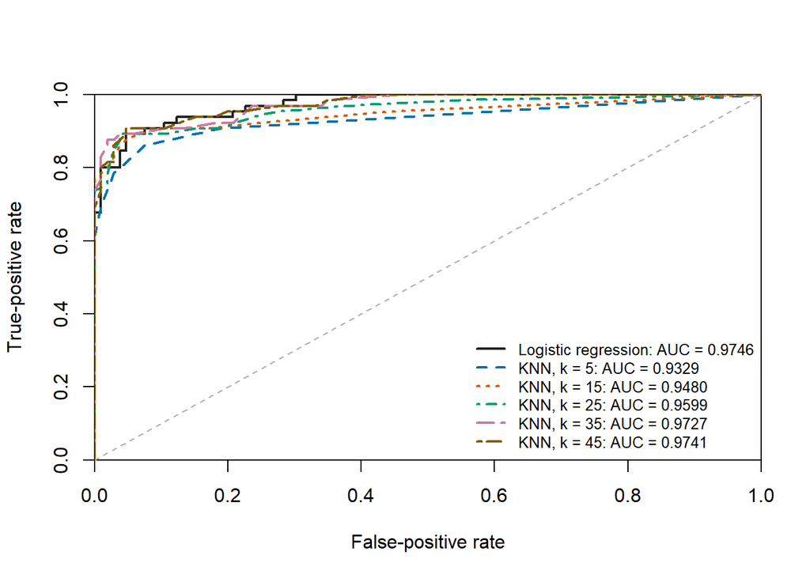

```r
colors <- c("#222222", "#0072B2", "#D55E00", "#009E73", "#CC79A7", "#806000")
line_types <- c(1, 2, 3, 4, 5, 6)
plot(c(0, 1), c(0, 1), type = "n", xaxs = "i", yaxs = "i",
     xlab = "False-positive rate", ylab = "True-positive rate")
abline(0, 1, col = "gray70", lty = 2)
for (m in seq_along(model_names)) {
  lines(1 - roc_test[[m]]$specificities, roc_test[[m]]$sensitivities,
        col = colors[m], lty = line_types[m], lwd = 2)
}
legend("bottomright", sprintf("%s: AUC = %.4f", model_names, auc_test),
       col = colors, lty = line_types, lwd = 2, cex = 0.8, bty = "n")
```

All six models show good discrimination between malignant and benign cases, with test AUC values above 0.93. Logistic regression has the highest test AUC (0.97), followed closely by KNN with k = 45 (0.97) and k = 35 (0.97). For KNN, the test AUC increases from 0.93 at k = 5 to 0.97 at k = 45, suggesting that averaging over more neighbors improves discrimination on this test set.

Among these six fitted models, I prefer logistic regression because it achieves the highest test AUC and provides a simple, interpretable model. However, its AUC advantage over KNN with k = 45 is only 0.0005, so these results do not establish a meaningful performance difference between them. The preference is based on this particular split; cross-validation within the training data would provide a more reliable basis for model selection.

## Question 2: Training and test ROC curves

Use the same data, training/test split, and standardization as in Question 1. Fit KNN with Euclidean distance, equal neighbor weights, and

$$k\in\{1,3,5,10,20\}.$$

Use each fitted model to estimate probabilities for both the training and test observations. For training predictions, include each observation itself among its $k$ nearest neighbors.

For each $k$, use a separate panel to show the training and test ROC curves together. Report both AUC values.

Explain the difference between training and test performance and how it changes with $k$. In particular, explain what happens at $k=1$ and why training performance may not reflect performance on new observations.

```r
k_values <- c(1, 3, 5, 10, 20)
p_train <- matrix(NA_real_, nrow(X_train), length(k_values))
p_test <- matrix(NA_real_, nrow(X_test), length(k_values))
roc_train <- roc_test <- vector("list", length(k_values))
auc_train <- auc_test <- numeric(length(k_values))
for (m in seq_along(k_values)) {
  k <- k_values[m]
  # test = X_train includes each training observation itself.
  p_train[, m] <- knn.reg(train = X_train, test = X_train,
                          y = y_train, k = k, algorithm = "brute")$pred
  p_test[, m] <- knn.reg(train = X_train, test = X_test,
                         y = y_train, k = k, algorithm = "brute")$pred
  roc_train[[m]] <- roc(y_train, p_train[, m], levels = c(0, 1),
                        direction = "<", quiet = TRUE)
  roc_test[[m]] <- roc(y_test, p_test[, m], levels = c(0, 1),
                       direction = "<", quiet = TRUE)
  auc_train[m] <- as.numeric(auc(roc_train[[m]]))
  auc_test[m] <- as.numeric(auc(roc_test[[m]]))
}
data.frame(k = k_values, Training_AUC = round(auc_train, 4),
           Test_AUC = round(auc_test, 4))
```

```
   k Training_AUC Test_AUC
1  1       1.0000   0.8764
2  3       0.9905   0.9138
3  5       0.9847   0.9329
4 10       0.9862   0.9446
5 20       0.9880   0.9586
```

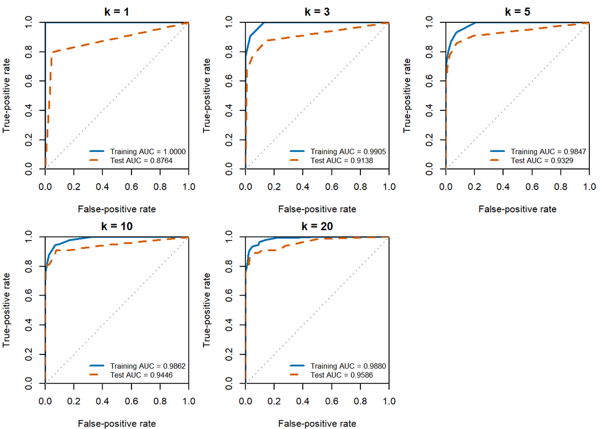

```r
old_par <- par(mfrow = c(2, 3), mar = c(4, 4, 2, 1))
for (m in seq_along(k_values)) {
  plot(1 - roc_train[[m]]$specificities, roc_train[[m]]$sensitivities,
       type = "l", col = "#0072B2", lwd = 2,
       xlim = c(0, 1), ylim = c(0, 1), xaxs = "i", yaxs = "i",
       main = paste("k =", k_values[m]),
       xlab = "False-positive rate", ylab = "True-positive rate")
  lines(1 - roc_test[[m]]$specificities, roc_test[[m]]$sensitivities,
        col = "#D55E00", lty = 2, lwd = 2)
  abline(0, 1, col = "gray70", lty = 3)
  legend("bottomright", c(sprintf("Training AUC = %.4f", auc_train[m]),
                          sprintf("Test AUC = %.4f", auc_test[m])),
         col = c("#0072B2", "#D55E00"), lty = c(1, 2), lwd = 2,
         cex = 0.8, bty = "n")
}
plot.new()
```

```r
par(old_par)
```

Training AUC is higher than test AUC for every value of k. The training/test AUC values are 1.0000/0.8764 for k = 1, 0.99/0.91 for k = 3, 0.98/0.93 for k = 5, 0.98/0.94 for k = 10, and 0.99/0.96 for k = 20. As k increases, test AUC improves and the gap between training and test performance becomes smaller. Training AUC initially decreases and then rises slightly, so it does not decrease monotonically.

At k = 1, each training observation is its own nearest neighbor because training predictions include the observation itself. Its predicted probability therefore equals its observed outcome: 1 for malignant cases and 0 for benign cases. This produces perfect separation and a training AUC of 1.0000. A new test observation does not have its own outcome available among the training neighbors, so its prediction depends on the label of the nearest training observation, which may belong to the wrong class. Thus, perfect training performance does not imply perfect performance on new observations.

With larger k, predicted probabilities average the outcomes of more neighbors. This reduces sensitivity to individual observations and local noise, helping explain the improvement in test AUC. The direct contribution of a training observation’s own outcome also decreases from 1 at k = 1 to 1/k. Nevertheless, training performance remains optimistic because it is evaluated using the same observations used to construct the predictions. Among the values examined, k = 20 has the highest test AUC, although increasing k further would not necessarily improve performance because overly large neighborhoods can smooth away useful local patterns.

## Question 3: Peer evaluation of Homework 5

You will receive two Homework 5 submissions to review. The instructor’s GitHub account, **rqzhu-aide**, will open a **GitHub Issue** in the repository containing your Homework 5 submission. It will contain links to two other students’ repositories, where you can find their submitted homework reports.

Open your repository’s **Issues** tab on GitHub to find the assignment. You may ask AI to explain GitHub Issues or help you locate the assignment.

Choose **one specific mistake or item for improvement** from any question in either report.

1. **Identify the mistake or item for improvement.** State which report and question you selected, and briefly describe what is wrong or could be improved. Examples include incorrect code, a calculation error, a misinterpretation of results, a plot that could communicate the findings more clearly, or anything else you think could be done better.
2. **Explain your assessment.** Quote the relevant text, code, or figure caption exactly. Explain why the selected answer is incorrect or how it could be improved, referring to its reasoning, calculations, code, figures, or interpretation. **Complete this part yourself, without AI assistance.**
3. **Provide a correction.** Write a corrected or improved answer to the selected question, including any calculations, code, or figures needed.

After completing your review, **open a GitHub Issue in the repository containing the report you selected**. Identify the report and question, and include your assessment and a detailed revision plan explaining what the author should change and why. Include a link to your posted GitHub Issue in your Homework 6 answer.

My peer review is here：https://github.com/mirgaon314/stat432-fall2026/issues/2